Florian CHARRIAT

03 Avril 2018

# Assemblage (ABYSS)

- 85 souches assemblées
> - 66 souches des terrasses
> - 19 souches séquencées par Adel
- Différentes tailles de k-mère utilisées pour chaque souche
> - Visualisation des statistiques de qualité pour choisir le meilleur assemblage pour chaque souche
> > - Sélection par N50
> > - Vérification de la sélection par visualisation des autres statistiques
- Visualisation de la qualité des 85 assemblages sélectionnés
> - Visualiser la qualité moyenne des assemblages
> - Filtrer les assemblages de mauvaise qualité

# Sélection du meilleur assemblage

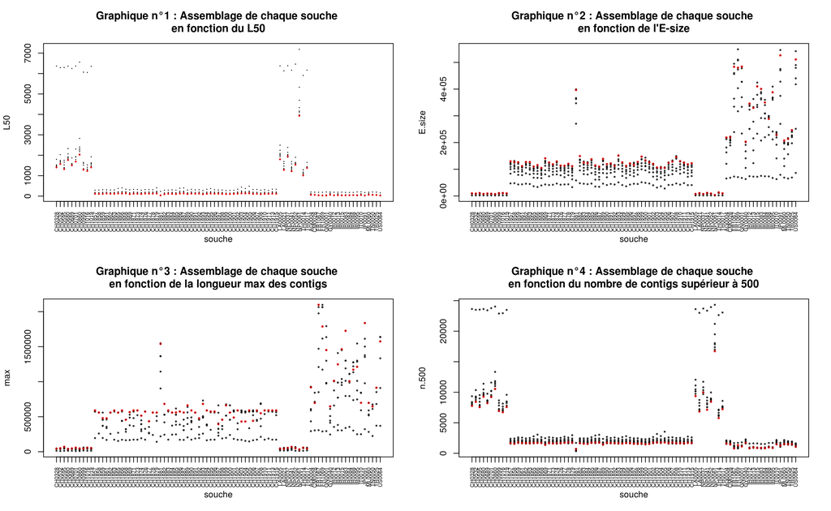

Les données et les graphiques sont aussi présents dans les rapports sur l’assemblage des souches des terrasses et l’assemblage des souches séquencé par Adel

# Visualision de la qualité des assemblages sélectionnés

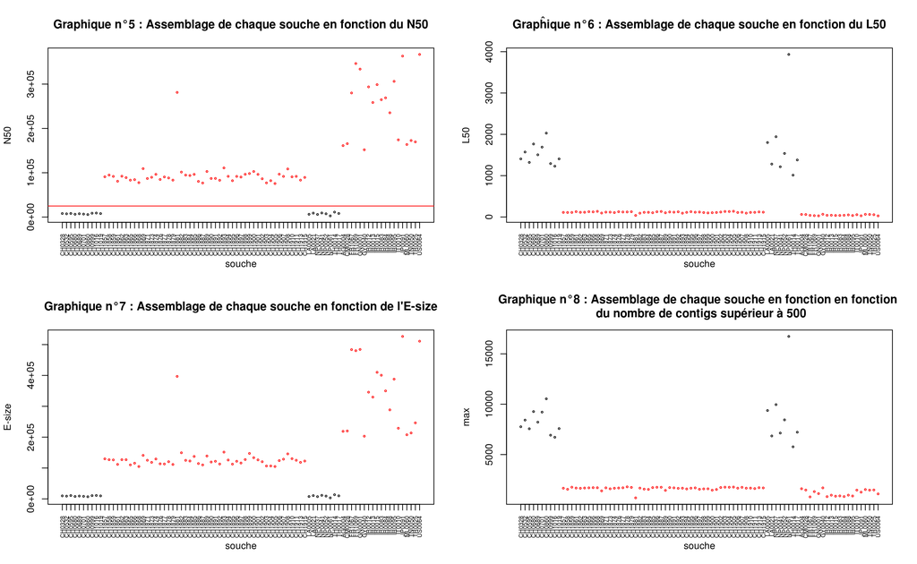

Les données et les graphiques sont aussi présents dans les rapports sur l’assemblage des souches des terrasses et l’assemblage des souches séquencé par Adel

# repeatMasker

- Masquer les éléments répétés des 67 souches sélectionnées.
- Pour chaque souche :
> - 4.67 à 8.18 % des séquences ont été masquées par repeatMasker
> - Dans les assemblages certains scaffolds ne sont constitués que d’éléments répétés
> > - Mise en place d’un script qui élimine ces scaffolds

Toutes les données sont présentes dans le rapport Masquer les éléments répétés

# Annotation (BRAKER)

- 154 souches à annoter :
> - 67 souches assemblées précédemment
> - 87 souches de la littérature
> - Plus des souches en cours de séquençage
- Pour annoter :

[figure not shown]

> Génome à annoter
> > - Choix de l’assemblage entre ceux effectués avec ABYSS et ceux réalisés par Sebastien

[figure not shown]

> Données RNAseq alignées avec le génome à annoter
> > - topHat : Aligner toutes les données RNAseq sélectionnées
> > - Samtools : Merger les alignements de chaque donnée RNAseq

# Mapping des RNAseq

- 32 données RNAseq sélectionnées
> - 2 données provenant du projet GEMO
> - 15 données de GY11
> - 3 données de Magnaburkho
> - 12 données InPlanta
- Traitement des données Inplanta :
> - Mapping sur le génome du riz pour récupérer seulement les reads de *Magnaporthe oryzae*
- Mise en forme des assemblages pour l’alignement :
> - Elimination des scaffolds de moins de 500 pb.
> - Les identifiants ont été modifié :
> > - Les scaffolds seront numérotés en fonction de leur longueur.
> > - En description de chaque scaffold sa longueur sera donnée.

Toutes les détails sont présent dans les rapports Choix des meilleurs Assemblages et Annotation